> **Tip**: Welcome to the Investigate a Dataset project! You will find tips in quoted sections like this to help organize your approach to your investigation. Once you complete this project, remove these **Tip** sections from your report before submission. First things first, you might want to double-click this Markdown cell and change the title so that it reflects your dataset and investigation.

# Project: Investigate a Dataset - NCIS and Census Data - Ikechukwu Ogbuchi

- Introduction
- Data Wrangling
- Exploratory Data Analysis
- Conclusions

## 1. Introduction

### Dataset Description

The data comes from the FBI's National Instant Criminal Background Check System. The NICS is used by to determine whether a prospective buyer is eligible to buy firearms or explosives. Gun shops call into this system to ensure that each customer does not have a criminal record or isn’t otherwise ineligible to make a purchase. The data has been supplemented with state level data from census.gov.

The NICS data is found in one sheet of an .xlsx file. It contains the number of firearm checks by month, state, and type. The U.S. census data is found in a .csv file. It contains several variables at the state level. Most variables just have one data point per state (2016), but a few have data for more than one year.

## 2. Question(s) for Analysis

```python
# Use this cell to set up import statements for all of the packages that you
#   plan to use.
import numpy as np
import pandas as pd
import matplotlib.pyplot as plt
import seaborn as sns
%matplotlib inline

# Remember to include a 'magic word' so that your visualizations are plotted
#   inline with the notebook. See this page for more:
#   http://ipython.readthedocs.io/en/stable/interactive/magics.html
```

```python
# Upgrade pandas to use dataframe.explode() function.
#!pip install --upgrade pandas==0.25.0
```

## 3. Data Wrangling

> *In this section, I loaded the data, checked for cleanliness, looked at the shape, orientation, trimmed off irrelevant columns, missing values and prepared my dataset for analysis.

### General Properties

> From the loaded data as shown in the code cells run below, we see from the Data Cleaning subsection that the gun dataframe 12485 rows and 27 columns. We also see that the census data frame in its initial orientation has 85 rows and 52 columns

```python
# Load your data and print out a few lines. Perform operations to inspect data
#   types and look for instances of missing or possibly errant data.
#Loading Data for NCIS gun data
gun_df = pd.read_excel('Database_Ncis_and_Census_data/gun_data.xlsx')
#Database_Ncis_and_Census_data/US_Census_Data.csv
gun_df.head()
```

|  | month | state | permit | permit_recheck | handgun | long_gun | other | multiple | admin | prepawn_handgun | ... | returned_other | rentals_handgun | rentals_long_gun | private_sale_handgun | private_sale_long_gun | private_sale_other | return_to_seller_handgun | return_to_seller_long_gun | return_to_seller_other | totals |
| --- | --- | --- | --- | --- | --- | --- | --- | --- | --- | --- | --- | --- | --- | --- | --- | --- | --- | --- | --- | --- | --- |
| 0 | 2017-09 | Alabama | 16717.0 | 0.0 | 5734.0 | 6320.0 | 221.0 | 317 | 0.0 | 15.0 | ... | 0.0 | 0.0 | 0.0 | 9.0 | 16.0 | 3.0 | 0.0 | 0.0 | 3.0 | 32019 |
| 1 | 2017-09 | Alaska | 209.0 | 2.0 | 2320.0 | 2930.0 | 219.0 | 160 | 0.0 | 5.0 | ... | 0.0 | 0.0 | 0.0 | 17.0 | 24.0 | 1.0 | 0.0 | 0.0 | 0.0 | 6303 |
| 2 | 2017-09 | Arizona | 5069.0 | 382.0 | 11063.0 | 7946.0 | 920.0 | 631 | 0.0 | 13.0 | ... | 0.0 | 0.0 | 0.0 | 38.0 | 12.0 | 2.0 | 0.0 | 0.0 | 0.0 | 28394 |
| 3 | 2017-09 | Arkansas | 2935.0 | 632.0 | 4347.0 | 6063.0 | 165.0 | 366 | 51.0 | 12.0 | ... | 0.0 | 0.0 | 0.0 | 13.0 | 23.0 | 0.0 | 0.0 | 2.0 | 1.0 | 17747 |
| 4 | 2017-09 | California | 57839.0 | 0.0 | 37165.0 | 24581.0 | 2984.0 | 0 | 0.0 | 0.0 | ... | 0.0 | 0.0 | 0.0 | 0.0 | 0.0 | 0.0 | 0.0 | 0.0 | 0.0 | 123506 |

5 rows × 27 columns

```python
#loading NCIS Census data

census_df=pd.read_csv('Database_Ncis_and_Census_data/US_Census_Data.csv')
census_df.head(5)
```

|  | Fact | Fact Note | Alabama | Alaska | Arizona | Arkansas | California | Colorado | Connecticut | Delaware | ... | South Dakota | Tennessee | Texas | Utah | Vermont | Virginia | Washington | West Virginia | Wisconsin | Wyoming |
| --- | --- | --- | --- | --- | --- | --- | --- | --- | --- | --- | --- | --- | --- | --- | --- | --- | --- | --- | --- | --- | --- |
| 0 | Population estimates, July 1, 2016, (V2016) | NaN | 4,863,300 | 741,894 | 6,931,071 | 2,988,248 | 39,250,017 | 5,540,545 | 3,576,452 | 952,065 | ... | 865454 | 6651194 | 27,862,596 | 3,051,217 | 624,594 | 8,411,808 | 7,288,000 | 1,831,102 | 5,778,708 | 585,501 |
| 1 | Population estimates base, April 1, 2010, (V2... | NaN | 4,780,131 | 710,249 | 6,392,301 | 2,916,025 | 37,254,522 | 5,029,324 | 3,574,114 | 897,936 | ... | 814195 | 6346298 | 25,146,100 | 2,763,888 | 625,741 | 8,001,041 | 6,724,545 | 1,853,011 | 5,687,289 | 563,767 |
| 2 | Population, percent change - April 1, 2010 (es... | NaN | 1.70% | 4.50% | 8.40% | 2.50% | 5.40% | 10.20% | 0.10% | 6.00% | ... | 0.063 | 0.048 | 10.80% | 10.40% | -0.20% | 5.10% | 8.40% | -1.20% | 1.60% | 3.90% |
| 3 | Population, Census, April 1, 2010 | NaN | 4,779,736 | 710,231 | 6,392,017 | 2,915,918 | 37,253,956 | 5,029,196 | 3,574,097 | 897,934 | ... | 814180 | 6346105 | 25,145,561 | 2,763,885 | 625,741 | 8,001,024 | 6,724,540 | 1,852,994 | 5,686,986 | 563,626 |
| 4 | Persons under 5 years, percent, July 1, 2016, ... | NaN | 6.00% | 7.30% | 6.30% | 6.40% | 6.30% | 6.10% | 5.20% | 5.80% | ... | 0.071 | 0.061 | 7.20% | 8.30% | 4.90% | 6.10% | 6.20% | 5.50% | 5.80% | 6.50% |

5 rows × 52 columns

### Observations

- For the gun data gun_df, the states are in a column named state, but in census_df, It appears these states are column headers.
- I want to transpose the census data to use the population column described as 'Fact' as column names, and to make the column headers become a column instead
- Will check for missing values first before transposing

```python
#Checking number of cols and rows with shape
census_df.shape
```

```
(85, 52)
```

```python
#85 Rows and 52 columns for Census data
#now check missing values
census_df.info()
```

```
<class 'pandas.core.frame.DataFrame'>
RangeIndex: 85 entries, 0 to 84
Data columns (total 52 columns):
Fact              80 non-null object
Fact Note         28 non-null object
Alabama           65 non-null object
Alaska            65 non-null object
Arizona           65 non-null object
Arkansas          65 non-null object
California        65 non-null object
Colorado          65 non-null object
Connecticut       65 non-null object
Delaware          65 non-null object
Florida           65 non-null object
Georgia           65 non-null object
Hawaii            65 non-null object
Idaho             65 non-null object
Illinois          65 non-null object
Indiana           65 non-null object
Iowa              65 non-null object
Kansas            65 non-null object
Kentucky          65 non-null object
Louisiana         65 non-null object
Maine             65 non-null object
Maryland          65 non-null object
Massachusetts     65 non-null object
Michigan          65 non-null object
Minnesota         65 non-null object
Mississippi       65 non-null object
Missouri          65 non-null object
Montana           65 non-null object
Nebraska          65 non-null object
Nevada            65 non-null object
New Hampshire     65 non-null object
New Jersey        65 non-null object
New Mexico        65 non-null object
New York          65 non-null object
North Carolina    65 non-null object
North Dakota      65 non-null object
Ohio              65 non-null object
Oklahoma          65 non-null object
Oregon            65 non-null object
Pennsylvania      65 non-null object
Rhode Island      65 non-null object
South Carolina    65 non-null object
South Dakota      65 non-null object
Tennessee         65 non-null object
Texas             65 non-null object
Utah              65 non-null object
Vermont           65 non-null object
Virginia          65 non-null object
Washington        65 non-null object
West Virginia     65 non-null object
Wisconsin         65 non-null object
Wyoming           65 non-null object
dtypes: object(52)
memory usage: 34.7+ KB
```

#### From the above, "Fact Note" has only 28 values and the rest missing, will terminate the column then transpose Census df

```python
#dropping Fact note
census_df.drop(columns=['Fact Note'],inplace=True)
```

```python
#Transposing
census_df=census_df.set_index('Fact').T
census_df
```

| Fact | Population estimates, July 1, 2016, (V2016) | Population estimates base, April 1, 2010, (V2016) | Population, percent change - April 1, 2010 (estimates base) to July 1, 2016, (V2016) | Population, Census, April 1, 2010 | Persons under 5 years, percent, July 1, 2016, (V2016) | Persons under 5 years, percent, April 1, 2010 | Persons under 18 years, percent, July 1, 2016, (V2016) | Persons under 18 years, percent, April 1, 2010 | Persons 65 years and over, percent, July 1, 2016, (V2016) | Persons 65 years and over, percent, April 1, 2010 | ... | NaN | Value Flags | - | D | F | FN | NaN | S | X | Z |
| --- | --- | --- | --- | --- | --- | --- | --- | --- | --- | --- | --- | --- | --- | --- | --- | --- | --- | --- | --- | --- | --- |
| Alabama | 4,863,300 | 4,780,131 | 1.70% | 4,779,736 | 6.00% | 6.40% | 22.60% | 23.70% | 16.10% | 13.80% | ... | NaN | NaN | NaN | NaN | NaN | NaN | NaN | NaN | NaN | NaN |
| Alaska | 741,894 | 710,249 | 4.50% | 710,231 | 7.30% | 7.60% | 25.20% | 26.40% | 10.40% | 7.70% | ... | NaN | NaN | NaN | NaN | NaN | NaN | NaN | NaN | NaN | NaN |
| Arizona | 6,931,071 | 6,392,301 | 8.40% | 6,392,017 | 6.30% | 7.10% | 23.50% | 25.50% | 16.90% | 13.80% | ... | NaN | NaN | NaN | NaN | NaN | NaN | NaN | NaN | NaN | NaN |
| Arkansas | 2,988,248 | 2,916,025 | 2.50% | 2,915,918 | 6.40% | 6.80% | 23.60% | 24.40% | 16.30% | 14.40% | ... | NaN | NaN | NaN | NaN | NaN | NaN | NaN | NaN | NaN | NaN |
| California | 39,250,017 | 37,254,522 | 5.40% | 37,253,956 | 6.30% | 6.80% | 23.20% | 25.00% | 13.60% | 11.40% | ... | NaN | NaN | NaN | NaN | NaN | NaN | NaN | NaN | NaN | NaN |
| Colorado | 5,540,545 | 5,029,324 | 10.20% | 5,029,196 | 6.10% | 6.80% | 22.80% | 24.40% | 13.40% | 10.90% | ... | NaN | NaN | NaN | NaN | NaN | NaN | NaN | NaN | NaN | NaN |
| Connecticut | 3,576,452 | 3,574,114 | 0.10% | 3,574,097 | 5.20% | 5.70% | 21.10% | 22.90% | 16.10% | 14.20% | ... | NaN | NaN | NaN | NaN | NaN | NaN | NaN | NaN | NaN | NaN |
| Delaware | 952,065 | 897,936 | 6.00% | 897,934 | 5.80% | 6.20% | 21.50% | 22.90% | 17.50% | 14.40% | ... | NaN | NaN | NaN | NaN | NaN | NaN | NaN | NaN | NaN | NaN |
| Florida | 20,612,439 | 18,804,592 | 9.60% | 18,801,310 | 5.50% | 5.70% | 20.10% | 21.30% | 19.90% | 17.30% | ... | NaN | NaN | NaN | NaN | NaN | NaN | NaN | NaN | NaN | NaN |
| Georgia | 10,310,371 | 9,688,680 | 6.40% | 9,687,653 | 6.40% | 7.10% | 24.40% | 25.70% | 13.10% | 10.70% | ... | NaN | NaN | NaN | NaN | NaN | NaN | NaN | NaN | NaN | NaN |
| Hawaii | 1,428,557 | 1,360,301 | 5.00% | 1,360,301 | 6.40% | 6.40% | 21.60% | 22.30% | 17.10% | 14.30% | ... | NaN | NaN | NaN | NaN | NaN | NaN | NaN | NaN | NaN | NaN |
| Idaho | 1,683,140 | 1,567,650 | 7.40% | 1,567,582 | 6.80% | 7.80% | 26.00% | 27.40% | 15.10% | 12.40% | ... | NaN | NaN | NaN | NaN | NaN | NaN | NaN | NaN | NaN | NaN |
| Illinois | 12,801,539 | 12,831,574 | -0.20% | 12,830,632 | 6.00% | 6.50% | 22.90% | 24.40% | 14.60% | 12.50% | ... | NaN | NaN | NaN | NaN | NaN | NaN | NaN | NaN | NaN | NaN |
| Indiana | 6,633,053 | 6,484,136 | 2.30% | 6,483,802 | 6.40% | 6.70% | 23.80% | 24.80% | 14.90% | 13.00% | ... | NaN | NaN | NaN | NaN | NaN | NaN | NaN | NaN | NaN | NaN |
| Iowa | 3,134,693 | 3,046,869 | 2.90% | 3,046,355 | 6.40% | 6.60% | 23.30% | 23.90% | 16.40% | 14.90% | ... | NaN | NaN | NaN | NaN | NaN | NaN | NaN | NaN | NaN | NaN |
| Kansas | 2,907,289 | 2,853,129 | 1.90% | 2,853,118 | 6.70% | 7.20% | 24.60% | 25.50% | 15.00% | 13.20% | ... | NaN | NaN | NaN | NaN | NaN | NaN | NaN | NaN | NaN | NaN |
| Kentucky | 4,436,974 | 4,339,344 | 2.20% | 4,339,367 | 6.20% | 6.50% | 22.80% | 23.60% | 15.60% | 13.30% | ... | NaN | NaN | NaN | NaN | NaN | NaN | NaN | NaN | NaN | NaN |
| Louisiana | 4,681,666 | 4,533,479 | 3.30% | 4,533,372 | 6.60% | 6.90% | 23.80% | 24.70% | 14.40% | 12.30% | ... | NaN | NaN | NaN | NaN | NaN | NaN | NaN | NaN | NaN | NaN |
| Maine | 1,331,479 | 1,328,364 | 0.20% | 1,328,361 | 4.90% | 5.20% | 19.10% | 20.70% | 19.40% | 15.90% | ... | NaN | NaN | NaN | NaN | NaN | NaN | NaN | NaN | NaN | NaN |
| Maryland | 6,016,447 | 5,773,786 | 4.20% | 5,773,552 | 6.10% | 6.30% | 22.40% | 23.40% | 14.60% | 12.30% | ... | NaN | NaN | NaN | NaN | NaN | NaN | NaN | NaN | NaN | NaN |
| Massachusetts | 6,811,779 | 6,547,813 | 4.00% | 6,547,629 | 5.30% | 5.60% | 20.20% | 21.70% | 15.80% | 13.80% | ... | NaN | NaN | NaN | NaN | NaN | NaN | NaN | NaN | NaN | NaN |
| Michigan | 9,928,300 | 9,884,129 | 0.40% | 9,883,640 | 5.80% | 6.00% | 22.10% | 23.70% | 16.20% | 13.80% | ... | NaN | NaN | NaN | NaN | NaN | NaN | NaN | NaN | NaN | NaN |
| Minnesota | 5,519,952 | 5,303,924 | 4.10% | 5,303,925 | 6.40% | 6.70% | 23.30% | 24.20% | 15.10% | 12.90% | ... | NaN | NaN | NaN | NaN | NaN | NaN | NaN | NaN | NaN | NaN |
| Mississippi | 2,988,726 | 2,968,103 | 0.70% | 2,967,297 | 6.30% | 7.10% | 24.10% | 25.50% | 15.10% | 12.80% | ... | NaN | NaN | NaN | NaN | NaN | NaN | NaN | NaN | NaN | NaN |
| Missouri | 6,093,000 | 5,988,928 | 1.70% | 5,988,927 | 6.10% | 6.50% | 22.80% | 23.80% | 16.10% | 14.00% | ... | NaN | NaN | NaN | NaN | NaN | NaN | NaN | NaN | NaN | NaN |
| Montana | 1,042,520 | 989,414 | 5.40% | 989,415 | 6.00% | 6.30% | 21.80% | 22.60% | 17.70% | 14.80% | ... | NaN | NaN | NaN | NaN | NaN | NaN | NaN | NaN | NaN | NaN |
| Nebraska | 1,907,116 | 1,826,334 | 4.40% | 1,826,341 | 7.00% | 7.20% | 24.80% | 25.10% | 15.00% | 13.50% | ... | NaN | NaN | NaN | NaN | NaN | NaN | NaN | NaN | NaN | NaN |
| Nevada | 2,940,058 | 2,700,691 | 8.90% | 2,700,551 | 6.30% | 6.90% | 23.00% | 24.60% | 15.00% | 12.00% | ... | NaN | NaN | NaN | NaN | NaN | NaN | NaN | NaN | NaN | NaN |
| New Hampshire | 1,334,795 | 1,316,461 | 1.40% | 1,316,470 | 4.80% | 5.30% | 19.50% | 21.80% | 17.00% | 13.50% | ... | NaN | NaN | NaN | NaN | NaN | NaN | NaN | NaN | NaN | NaN |
| New Jersey | 8,944,469 | 8,791,953 | 1.70% | 8,791,894 | 5.80% | 6.20% | 22.20% | 23.50% | 15.30% | 13.50% | ... | NaN | NaN | NaN | NaN | NaN | NaN | NaN | NaN | NaN | NaN |
| New Mexico | 2081015 | 2059198 | 0.011 | 2059179 | 0.062 | 0.07 | 0.236 | 0.252 | 0.165 | 0.132 | ... | NaN | NaN | NaN | NaN | NaN | NaN | NaN | NaN | NaN | NaN |
| New York | 19745289 | 19378110 | 0.019 | 19378102 | 0.059 | 0.06 | 0.212 | 0.223 | 0.154 | 0.135 | ... | NaN | NaN | NaN | NaN | NaN | NaN | NaN | NaN | NaN | NaN |
| North Carolina | 10146788 | 9535688 | 0.064 | 9535483 | 0.06 | 0.066 | 0.227 | 0.239 | 0.155 | 0.129 | ... | NaN | NaN | NaN | NaN | NaN | NaN | NaN | NaN | NaN | NaN |
| North Dakota | 757952 | 672591 | 0.127 | 672591 | 0.073 | 0.066 | 0.233 | 0.223 | 0.145 | 0.145 | ... | NaN | NaN | NaN | NaN | NaN | NaN | NaN | NaN | NaN | NaN |
| Ohio | 11614373 | 11536727 | 0.007 | 11536504 | 0.06 | 0.062 | 0.225 | 0.237 | 0.162 | 0.141 | ... | NaN | NaN | NaN | NaN | NaN | NaN | NaN | NaN | NaN | NaN |
| Oklahoma | 3923561 | 3751615 | 0.046 | 3751351 | 0.068 | 0.07 | 0.245 | 0.248 | 0.15 | 0.135 | ... | NaN | NaN | NaN | NaN | NaN | NaN | NaN | NaN | NaN | NaN |
| Oregon | 4093465 | 3831072 | 0.068 | 3831074 | 0.058 | 0.062 | 0.212 | 0.226 | 0.168 | 0.139 | ... | NaN | NaN | NaN | NaN | NaN | NaN | NaN | NaN | NaN | NaN |
| Pennsylvania | 12784227 | 12702857 | 0.006 | 12702379 | 0.056 | 0.057 | 0.209 | 0.22 | 0.174 | 0.154 | ... | NaN | NaN | NaN | NaN | NaN | NaN | NaN | NaN | NaN | NaN |
| Rhode Island | 1056426 | 1052940 | 0.003 | 1052567 | 0.052 | 0.055 | 0.197 | 0.213 | 0.165 | 0.144 | ... | NaN | NaN | NaN | NaN | NaN | NaN | NaN | NaN | NaN | NaN |
| South Carolina | 4961119 | 4625410 | 0.073 | 4625364 | 0.059 | 0.065 | 0.221 | 0.234 | 0.167 | 0.137 | ... | NaN | NaN | NaN | NaN | NaN | NaN | NaN | NaN | NaN | NaN |
| South Dakota | 865454 | 814195 | 0.063 | 814180 | 0.071 | 0.073 | 0.246 | 0.249 | 0.16 | 0.143 | ... | NaN | NaN | NaN | NaN | NaN | NaN | NaN | NaN | NaN | NaN |
| Tennessee | 6651194 | 6346298 | 0.048 | 6346105 | 0.061 | 0.064 | 0.226 | 0.236 | 0.157 | 0.134 | ... | NaN | NaN | NaN | NaN | NaN | NaN | NaN | NaN | NaN | NaN |
| Texas | 27,862,596 | 25,146,100 | 10.80% | 25,145,561 | 7.20% | 7.70% | 26.20% | 27.30% | 12.00% | 10.30% | ... | NaN | NaN | NaN | NaN | NaN | NaN | NaN | NaN | NaN | NaN |
| Utah | 3,051,217 | 2,763,888 | 10.40% | 2,763,885 | 8.30% | 9.50% | 30.20% | 31.50% | 10.50% | 9.00% | ... | NaN | NaN | NaN | NaN | NaN | NaN | NaN | NaN | NaN | NaN |
| Vermont | 624,594 | 625,741 | -0.20% | 625,741 | 4.90% | 5.10% | 19.00% | 20.70% | 18.10% | 14.60% | ... | NaN | NaN | NaN | NaN | NaN | NaN | NaN | NaN | NaN | NaN |
| Virginia | 8,411,808 | 8,001,041 | 5.10% | 8,001,024 | 6.10% | 6.40% | 22.20% | 23.20% | 14.60% | 12.20% | ... | NaN | NaN | NaN | NaN | NaN | NaN | NaN | NaN | NaN | NaN |
| Washington | 7,288,000 | 6,724,545 | 8.40% | 6,724,540 | 6.20% | 6.50% | 22.40% | 23.50% | 14.80% | 12.30% | ... | NaN | NaN | NaN | NaN | NaN | NaN | NaN | NaN | NaN | NaN |
| West Virginia | 1,831,102 | 1,853,011 | -1.20% | 1,852,994 | 5.50% | 5.60% | 20.50% | 20.90% | 18.80% | 16.00% | ... | NaN | NaN | NaN | NaN | NaN | NaN | NaN | NaN | NaN | NaN |
| Wisconsin | 5,778,708 | 5,687,289 | 1.60% | 5,686,986 | 5.80% | 6.30% | 22.30% | 23.60% | 16.10% | 13.70% | ... | NaN | NaN | NaN | NaN | NaN | NaN | NaN | NaN | NaN | NaN |
| Wyoming | 585,501 | 563,767 | 3.90% | 563,626 | 6.50% | 7.10% | 23.70% | 24.00% | 15.00% | 12.40% | ... | NaN | NaN | NaN | NaN | NaN | NaN | NaN | NaN | NaN | NaN |

50 rows × 85 columns

```python
#Resetting index, so state names are not index
census_df = census_df.reset_index()
census_df.head(2)
```

| Fact | index | Population estimates, July 1, 2016, (V2016) | Population estimates base, April 1, 2010, (V2016) | Population, percent change - April 1, 2010 (estimates base) to July 1, 2016, (V2016) | Population, Census, April 1, 2010 | Persons under 5 years, percent, July 1, 2016, (V2016) | Persons under 5 years, percent, April 1, 2010 | Persons under 18 years, percent, July 1, 2016, (V2016) | Persons under 18 years, percent, April 1, 2010 | Persons 65 years and over, percent, July 1, 2016, (V2016) | ... | NaN | Value Flags | - | D | F | FN | NaN | S | X | Z |
| --- | --- | --- | --- | --- | --- | --- | --- | --- | --- | --- | --- | --- | --- | --- | --- | --- | --- | --- | --- | --- | --- |
| 0 | Alabama | 4,863,300 | 4,780,131 | 1.70% | 4,779,736 | 6.00% | 6.40% | 22.60% | 23.70% | 16.10% | ... | NaN | NaN | NaN | NaN | NaN | NaN | NaN | NaN | NaN | NaN |
| 1 | Alaska | 741,894 | 710,249 | 4.50% | 710,231 | 7.30% | 7.60% | 25.20% | 26.40% | 10.40% | ... | NaN | NaN | NaN | NaN | NaN | NaN | NaN | NaN | NaN | NaN |

2 rows × 86 columns

```python
#checking new shape
census_df.shape
```

```
(50, 86)
```

### Data Cleaning

> **Tip**: Make sure that you keep your reader informed on the steps that you are taking in your investigation. Follow every code cell, or every set of related code cells, with a markdown cell to describe to the reader what was found in the preceding cell(s). Try to make it so that the reader can then understand what they will be seeing in the following cell(s).

#### In this section Data Cleaning, I will check for all duplicates, nan values, describe the data and preview all column names

```python
#Checking for duplicates in gun_df and census_df
print(sum(census_df.duplicated()))
print(sum(gun_df.duplicated()))
```

```
0
0
```

```python
#Checking for sum of nan values in both census and gun df
print(gun_df.isna().sum())
print(census_df.isna().sum().tail(25))
```

```
month                            0
state                            0
permit                          24
permit_recheck               11385
handgun                         20
long_gun                        19
other                         6985
multiple                         0
admin                           23
prepawn_handgun               1943
prepawn_long_gun              1945
prepawn_other                 7370
redemption_handgun            1940
redemption_long_gun           1941
redemption_other              7370
returned_handgun             10285
returned_long_gun            10340
returned_other               10670
rentals_handgun              11495
rentals_long_gun             11660
private_sale_handgun          9735
private_sale_long_gun         9735
private_sale_other            9735
return_to_seller_handgun     10010
return_to_seller_long_gun     9735
return_to_seller_other       10230
totals                           0
dtype: int64
Fact
Veteran-owned firms, 2012                                                                0
Nonveteran-owned firms, 2012                                                             0
Population per square mile, 2010                                                         0
Land area in square miles, 2010                                                          0
FIPS Code                                                                                0
NaN                                                                                     50
NOTE: FIPS Code values are enclosed in quotes to ensure leading zeros remain intact.    50
NaN                                                                                     50
Value Notes                                                                             50
1                                                                                       50
NaN                                                                                     50
Fact Notes                                                                              50
(a)                                                                                     50
(b)                                                                                     50
(c)                                                                                     50
NaN                                                                                     50
Value Flags                                                                             50
-                                                                                       50
D                                                                                       50
F                                                                                       50
FN                                                                                      50
NaN                                                                                     50
S                                                                                       50
X                                                                                       50
Z                                                                                       50
dtype: int64
```

##### We can see there are a lot of missing values, for the census data which was transposed, most of the data is occurring towards the end columns. will remove the columns with all missing values and replace them with mean

```python
#previewing shape of both datasets
print(gun_df.shape)
print(census_df.shape)
```

```
(12485, 27)
(50, 86)
```

```python
#filling all missing values from gun_df with mean of each row value
gun_df=gun_df.fillna(gun_df.mean)
#checking again for missing values
print(gun_df.isna().sum())
```

```
month                        0
state                        0
permit                       0
permit_recheck               0
handgun                      0
long_gun                     0
other                        0
multiple                     0
admin                        0
prepawn_handgun              0
prepawn_long_gun             0
prepawn_other                0
redemption_handgun           0
redemption_long_gun          0
redemption_other             0
returned_handgun             0
returned_long_gun            0
returned_other               0
rentals_handgun              0
rentals_long_gun             0
private_sale_handgun         0
private_sale_long_gun        0
private_sale_other           0
return_to_seller_handgun     0
return_to_seller_long_gun    0
return_to_seller_other       0
totals                       0
dtype: int64
```

```python
#Doing the same for Census_df, but have to remove the last tail rows with all missing values first
#previewing all rows
census_df.columns
```

```
Index([                                                                                 'index',
                                                 'Population estimates, July 1, 2016,  (V2016)',
                                           'Population estimates base, April 1, 2010,  (V2016)',
        'Population, percent change - April 1, 2010 (estimates base) to July 1, 2016,  (V2016)',
                                                            'Population, Census, April 1, 2010',
                                       'Persons under 5 years, percent, July 1, 2016,  (V2016)',
                                                'Persons under 5 years, percent, April 1, 2010',
                                      'Persons under 18 years, percent, July 1, 2016,  (V2016)',
                                               'Persons under 18 years, percent, April 1, 2010',
                                  'Persons 65 years and over, percent,  July 1, 2016,  (V2016)',
                                            'Persons 65 years and over, percent, April 1, 2010',
                                             'Female persons, percent,  July 1, 2016,  (V2016)',
                                                       'Female persons, percent, April 1, 2010',
                                                 'White alone, percent, July 1, 2016,  (V2016)',
                             'Black or African American alone, percent, July 1, 2016,  (V2016)',
                     'American Indian and Alaska Native alone, percent, July 1, 2016,  (V2016)',
                                                 'Asian alone, percent, July 1, 2016,  (V2016)',
            'Native Hawaiian and Other Pacific Islander alone, percent, July 1, 2016,  (V2016)',
                                           'Two or More Races, percent, July 1, 2016,  (V2016)',
                                          'Hispanic or Latino, percent, July 1, 2016,  (V2016)',
                         'White alone, not Hispanic or Latino, percent, July 1, 2016,  (V2016)',
                                                                          'Veterans, 2011-2015',
                                                     'Foreign born persons, percent, 2011-2015',
                                                       'Housing units,  July 1, 2016,  (V2016)',
                                                                 'Housing units, April 1, 2010',
                                                  'Owner-occupied housing unit rate, 2011-2015',
                                      'Median value of owner-occupied housing units, 2011-2015',
                              'Median selected monthly owner costs -with a mortgage, 2011-2015',
                           'Median selected monthly owner costs -without a mortgage, 2011-2015',
                                                                 'Median gross rent, 2011-2015',
                                                                       'Building permits, 2016',
                                                                        'Households, 2011-2015',
                                                             'Persons per household, 2011-2015',
                   'Living in same house 1 year ago, percent of persons age 1 year+, 2011-2015',
       'Language other than English spoken at home, percent of persons age 5 years+, 2011-2015',
                  'High school graduate or higher, percent of persons age 25 years+, 2011-2015',
                     'Bachelor's degree or higher, percent of persons age 25 years+, 2011-2015',
                                    'With a disability, under age 65 years, percent, 2011-2015',
                               'Persons  without health insurance, under age 65 years, percent',
               'In civilian labor force, total, percent of population age 16 years+, 2011-2015',
```

[output cut: 32 more lines]

```
                                                                                   'Fact Notes',
                                                                                          '(a)',
                                                                                          '(b)',
                                                                                          '(c)',
                                                                                            nan,
                                                                                  'Value Flags',
                                                                                            '-',
                                                                                            'D',
                                                                                            'F',
                                                                                           'FN',
                                                                                            nan,
                                                                                            'S',
                                                                                            'X',
                                                                                            'Z'],
      dtype='object', name='Fact')
```

```python
#As seen from the cell checking census_df nan.. the all missing columns start after 'FIPS Code' column.
#will eliminate every other column after that
#Getting location of FIPS Code
print(census_df.columns.get_loc("FIPS Code"))
```

```
65
```

```python
census_df=census_df.iloc[:,0:66]
census_df
```

| Fact | index | Population estimates, July 1, 2016, (V2016) | Population estimates base, April 1, 2010, (V2016) | Population, percent change - April 1, 2010 (estimates base) to July 1, 2016, (V2016) | Population, Census, April 1, 2010 | Persons under 5 years, percent, July 1, 2016, (V2016) | Persons under 5 years, percent, April 1, 2010 | Persons under 18 years, percent, July 1, 2016, (V2016) | Persons under 18 years, percent, April 1, 2010 | Persons 65 years and over, percent, July 1, 2016, (V2016) | ... | All firms, 2012 | Men-owned firms, 2012 | Women-owned firms, 2012 | Minority-owned firms, 2012 | Nonminority-owned firms, 2012 | Veteran-owned firms, 2012 | Nonveteran-owned firms, 2012 | Population per square mile, 2010 | Land area in square miles, 2010 | FIPS Code |
| --- | --- | --- | --- | --- | --- | --- | --- | --- | --- | --- | --- | --- | --- | --- | --- | --- | --- | --- | --- | --- | --- |
| 0 | Alabama | 4,863,300 | 4,780,131 | 1.70% | 4,779,736 | 6.00% | 6.40% | 22.60% | 23.70% | 16.10% | ... | 374,153 | 203,604 | 137,630 | 92,219 | 272,651 | 41,943 | 316,984 | 94.4 | 50,645.33 | "01" |
| 1 | Alaska | 741,894 | 710,249 | 4.50% | 710,231 | 7.30% | 7.60% | 25.20% | 26.40% | 10.40% | ... | 68,032 | 35,402 | 22,141 | 13,688 | 51,147 | 7,953 | 56,091 | 1.2 | 570,640.95 | "02" |
| 2 | Arizona | 6,931,071 | 6,392,301 | 8.40% | 6,392,017 | 6.30% | 7.10% | 23.50% | 25.50% | 16.90% | ... | 499,926 | 245,243 | 182,425 | 135,313 | 344,981 | 46,780 | 427,582 | 56.3 | 113,594.08 | "04" |
| 3 | Arkansas | 2,988,248 | 2,916,025 | 2.50% | 2,915,918 | 6.40% | 6.80% | 23.60% | 24.40% | 16.30% | ... | 231,959 | 123,158 | 75,962 | 35,982 | 189,029 | 25,915 | 192,988 | 56 | 52,035.48 | "05" |
| 4 | California | 39,250,017 | 37,254,522 | 5.40% | 37,253,956 | 6.30% | 6.80% | 23.20% | 25.00% | 13.60% | ... | 3,548,449 | 1,852,580 | 1,320,085 | 1,619,857 | 1,819,107 | 252,377 | 3,176,341 | 239.1 | 155,779.22 | "06" |
| 5 | Colorado | 5,540,545 | 5,029,324 | 10.20% | 5,029,196 | 6.10% | 6.80% | 22.80% | 24.40% | 13.40% | ... | 547,352 | 284,554 | 194,508 | 85,849 | 442,365 | 51,722 | 469,524 | 48.5 | 103,641.89 | "08" |
| 6 | Connecticut | 3,576,452 | 3,574,114 | 0.10% | 3,574,097 | 5.20% | 5.70% | 21.10% | 22.90% | 16.10% | ... | 326,693 | 187,845 | 106,678 | 56,113 | 259,614 | 31,056 | 281,182 | 738.1 | 4,842.36 | "09" |
| 7 | Delaware | 952,065 | 897,936 | 6.00% | 897,934 | 5.80% | 6.20% | 21.50% | 22.90% | 17.50% | ... | 73,418 | 38,328 | 23,964 | 14,440 | 54,782 | 7,206 | 60,318 | 460.8 | 1,948.54 | "10" |
| 8 | Florida | 20,612,439 | 18,804,592 | 9.60% | 18,801,310 | 5.50% | 5.70% | 20.10% | 21.30% | 19.90% | ... | 2,100,187 | 1,084,885 | 807,817 | 926,112 | 1,121,749 | 185,756 | 1,846,686 | 350.6 | 53,624.76 | "12" |
| 9 | Georgia | 10,310,371 | 9,688,680 | 6.40% | 9,687,653 | 6.40% | 7.10% | 24.40% | 25.70% | 13.10% | ... | 929,864 | 480,578 | 376,506 | 371,588 | 538,893 | 96,787 | 800,585 | 168.4 | 57,513.49 | "13" |
| 10 | Hawaii | 1,428,557 | 1,360,301 | 5.00% | 1,360,301 | 6.40% | 6.40% | 21.60% | 22.30% | 17.10% | ... | 118,454 | 60,409 | 44,453 | 74,208 | 38,510 | 11,148 | 101,334 | 211.8 | 6,422.63 | "15" |
| 11 | Idaho | 1,683,140 | 1,567,650 | 7.40% | 1,567,582 | 6.80% | 7.80% | 26.00% | 27.40% | 15.10% | ... | 146,642 | 70,438 | 45,121 | 10,592 | 130,973 | 12,804 | 124,314 | 19 | 82,643.12 | "16" |
| 12 | Illinois | 12,801,539 | 12,831,574 | -0.20% | 12,830,632 | 6.00% | 6.50% | 22.90% | 24.40% | 14.60% | ... | 1,135,017 | 609,648 | 417,500 | 311,684 | 795,129 | 89,110 | 1,006,885 | 231.1 | 55,518.93 | "17" |
| 13 | Indiana | 6,633,053 | 6,484,136 | 2.30% | 6,483,802 | 6.40% | 6.70% | 23.80% | 24.80% | 14.90% | ... | 479,059 | 253,533 | 162,798 | 61,252 | 405,090 | 45,174 | 412,543 | 181 | 35,826.11 | "18" |
| 14 | Iowa | 3,134,693 | 3,046,869 | 2.90% | 3,046,355 | 6.40% | 6.60% | 23.30% | 23.90% | 16.40% | ... | 259,121 | 135,382 | 82,345 | 14,707 | 236,561 | 25,889 | 217,779 | 54.5 | 55,857.13 | "19" |
| 15 | Kansas | 2,907,289 | 2,853,129 | 1.90% | 2,853,118 | 6.70% | 7.20% | 24.60% | 25.50% | 15.00% | ... | 239,118 | 125,169 | 77,194 | 26,127 | 204,562 | 21,610 | 203,401 | 34.9 | 81,758.72 | "20" |
| 16 | Kentucky | 4,436,974 | 4,339,344 | 2.20% | 4,339,367 | 6.20% | 6.50% | 22.80% | 23.60% | 15.60% | ... | 331,546 | 184,154 | 106,011 | 27,258 | 296,155 | 33,208 | 282,704 | 109.9 | 39,486.34 | "21" |
| 17 | Louisiana | 4,681,666 | 4,533,479 | 3.30% | 4,533,372 | 6.60% | 6.90% | 23.80% | 24.70% | 14.40% | ... | 414,291 | 215,111 | 151,114 | 126,100 | 277,676 | 42,211 | 354,460 | 104.9 | 43,203.90 | "22" |
| 18 | Maine | 1,331,479 | 1,328,364 | 0.20% | 1,328,361 | 4.90% | 5.20% | 19.10% | 20.70% | 19.40% | ... | 139,570 | 79,243 | 42,067 | 4,339 | 131,322 | 15,689 | 115,839 | 43.1 | 30,842.92 | "23" |
| 19 | Maryland | 6,016,447 | 5,773,786 | 4.20% | 5,773,552 | 6.10% | 6.30% | 22.40% | 23.40% | 14.60% | ... | 531,953 | 276,630 | 209,119 | 203,394 | 314,902 | 50,976 | 462,232 | 594.8 | 9,707.24 | "24" |
| 20 | Massachusetts | 6,811,779 | 6,547,813 | 4.00% | 6,547,629 | 5.30% | 5.60% | 20.20% | 21.70% | 15.80% | ... | 607,664 | 357,158 | 199,210 | 89,967 | 499,959 | 58,339 | 525,667 | 839.4 | 7,800.06 | "25" |
| 21 | Michigan | 9,928,300 | 9,884,129 | 0.40% | 9,883,640 | 5.80% | 6.00% | 22.10% | 23.70% | 16.20% | ... | 834,087 | 446,128 | 306,986 | 158,946 | 657,237 | 71,861 | 733,517 | 174.8 | 56,538.90 | "26" |
| 22 | Minnesota | 5,519,952 | 5,303,924 | 4.10% | 5,303,925 | 6.40% | 6.70% | 23.30% | 24.20% | 15.10% | ... | 489,494 | 268,710 | 157,821 | 47,302 | 428,716 | 45,582 | 419,628 | 66.6 | 79,626.74 | "27" |
| 23 | Mississippi | 2,988,726 | 2,968,103 | 0.70% | 2,967,297 | 6.30% | 7.10% | 24.10% | 25.50% | 15.10% | ... | 235,454 | 125,079 | 89,159 | 74,824 | 155,094 | 26,789 | 198,566 | 63.2 | 46,923.27 | "28" |
| 24 | Missouri | 6,093,000 | 5,988,928 | 1.70% | 5,988,927 | 6.10% | 6.50% | 22.80% | 23.80% | 16.10% | ... | 491,606 | 257,948 | 162,616 | 61,035 | 415,972 | 49,217 | 415,542 | 87.1 | 68,741.52 | "29" |
| 25 | Montana | 1,042,520 | 989,414 | 5.40% | 989,415 | 6.00% | 6.30% | 21.80% | 22.60% | 17.70% | ... | 112,419 | 55,913 | 35,449 | 5,578 | 102,746 | 11,486 | 93,393 | 6.8 | 145,545.80 | "30" |
| 26 | Nebraska | 1,907,116 | 1,826,334 | 4.40% | 1,826,341 | 7.00% | 7.20% | 24.80% | 25.10% | 15.00% | ... | 164,089 | 83,696 | 51,936 | 14,571 | 144,122 | 16,693 | 137,254 | 23.8 | 76,824.17 | "31" |
| 27 | Nevada | 2,940,058 | 2,700,691 | 8.90% | 2,700,551 | 6.30% | 6.90% | 23.00% | 24.60% | 15.00% | ... | 227,156 | 114,057 | 82,508 | 71,864 | 144,944 | 23,049 | 191,293 | 24.6 | 109,781.18 | "32" |
| 28 | New Hampshire | 1,334,795 | 1,316,461 | 1.40% | 1,316,470 | 4.80% | 5.30% | 19.50% | 21.80% | 17.00% | ... | 131,638 | 76,716 | 38,525 | 6,111 | 121,297 | 16,119 | 108,817 | 147 | 8,952.65 | "33" |
| 29 | New Jersey | 8,944,469 | 8,791,953 | 1.70% | 8,791,894 | 5.80% | 6.20% | 22.20% | 23.50% | 15.30% | ... | 792,088 | 464,592 | 252,944 | 237,242 | 533,808 | 57,996 | 707,975 | 1,195.50 | 7,354.22 | "34" |
| 30 | New Mexico | 2081015 | 2059198 | 0.011 | 2059179 | 0.062 | 0.07 | 0.236 | 0.252 | 0.165 | ... | 151363 | 71132 | 59044 | 60622 | 83857 | 14096 | 128693 | 17 | 121298.15 | "35" |
| 31 | New York | 19745289 | 19378110 | 0.019 | 19378102 | 0.059 | 0.06 | 0.212 | 0.223 | 0.154 | ... | 2008988 | 1139910 | 725709 | 709021 | 1248304 | 137532 | 1811544 | 411.2 | 47126.4 | "36" |
| 32 | North Carolina | 10146788 | 9535688 | 0.064 | 9535483 | 0.06 | 0.066 | 0.227 | 0.239 | 0.155 | ... | 805985 | 435677 | 287058 | 183380 | 603182 | 86571 | 684743 | 196.1 | 48617.91 | "37" |
| 33 | North Dakota | 757952 | 672591 | 0.127 | 672591 | 0.073 | 0.066 | 0.233 | 0.223 | 0.145 | ... | 68270 | 37016 | 20316 | 3190 | 62271 | 6584 | 56904 | 9.7 | 69000.8 | "38" |
| 34 | Ohio | 11614373 | 11536727 | 0.007 | 11536504 | 0.06 | 0.062 | 0.225 | 0.237 | 0.162 | ... | 904814 | 510078 | 306824 | 122653 | 759569 | 91316 | 776193 | 282.3 | 40860.69 | "39" |
| 35 | Oklahoma | 3923561 | 3751615 | 0.046 | 3751351 | 0.068 | 0.07 | 0.245 | 0.248 | 0.15 | ... | 327229 | 174395 | 105168 | 64875 | 249027 | 36273 | 273491 | 54.7 | 68594.92 | "40" |
| 36 | Oregon | 4093465 | 3831072 | 0.068 | 3831074 | 0.058 | 0.062 | 0.212 | 0.226 | 0.168 | ... | 339305 | 165691 | 123015 | 41456 | 285028 | 30918 | 288790 | 39.9 | 95988.01 | "41" |
| 37 | Pennsylvania | 12784227 | 12702857 | 0.006 | 12702379 | 0.056 | 0.057 | 0.209 | 0.22 | 0.174 | ... | 975453 | 579400 | 304803 | 131512 | 818858 | 97969 | 837792 | 283.9 | 44742.7 | "42" |
| 38 | Rhode Island | 1056426 | 1052940 | 0.003 | 1052567 | 0.052 | 0.055 | 0.197 | 0.213 | 0.165 | ... | 94642 | 54651 | 30484 | 14737 | 77042 | 9904 | 79837 | 1018.1 | 1033.81 | "44" |
| 39 | South Carolina | 4961119 | 4625410 | 0.073 | 4625364 | 0.059 | 0.065 | 0.221 | 0.234 | 0.167 | ... | 367726 | 202446 | 131856 | 83233 | 276269 | 47987 | 303137 | 153.9 | 30060.7 | "45" |
| 40 | South Dakota | 865454 | 814195 | 0.063 | 814180 | 0.071 | 0.073 | 0.246 | 0.249 | 0.16 | ... | 81314 | 42418 | 23722 | 4101 | 74228 | 8604 | 66219 | 10.7 | 75811 | "46" |
| 41 | Tennessee | 6651194 | 6346298 | 0.048 | 6346105 | 0.061 | 0.064 | 0.226 | 0.236 | 0.157 | ... | 550453 | 302249 | 195694 | 105234 | 434025 | 59379 | 469392 | 153.9 | 41234.9 | "47" |
| 42 | Texas | 27,862,596 | 25,146,100 | 10.80% | 25,145,561 | 7.20% | 7.70% | 26.20% | 27.30% | 12.00% | ... | 2,356,748 | 1,251,696 | 866,678 | 1,070,392 | 1,224,845 | 213,590 | 2,057,218 | 96.3 | 261,231.71 | "48" |
| 43 | Utah | 3,051,217 | 2,763,888 | 10.40% | 2,763,885 | 8.30% | 9.50% | 30.20% | 31.50% | 10.50% | ... | 251,419 | 132,163 | 76,269 | 24,423 | 218,826 | 18,754 | 219,807 | 33.6 | 82,169.62 | "49" |
| 44 | Vermont | 624,594 | 625,741 | -0.20% | 625,741 | 4.90% | 5.10% | 19.00% | 20.70% | 18.10% | ... | 75,827 | 41,270 | 23,417 | 2,354 | 70,491 | 8,237 | 63,317 | 67.9 | 9,216.66 | "50" |
| 45 | Virginia | 8,411,808 | 8,001,041 | 5.10% | 8,001,024 | 6.10% | 6.40% | 22.20% | 23.20% | 14.60% | ... | 653,193 | 353,012 | 236,290 | 185,043 | 450,109 | 76,434 | 548,439 | 202.6 | 39,490.09 | "51" |
| 46 | Washington | 7,288,000 | 6,724,545 | 8.40% | 6,724,540 | 6.20% | 6.50% | 22.40% | 23.50% | 14.80% | ... | 541,522 | 262,650 | 187,677 | 92,807 | 426,697 | 49,331 | 461,401 | 101.2 | 66,455.52 | "53" |
| 47 | West Virginia | 1,831,102 | 1,853,011 | -1.20% | 1,852,994 | 5.50% | 5.60% | 20.50% | 20.90% | 18.80% | ... | 114,435 | 63,112 | 39,065 | 5,777 | 104,785 | 12,912 | 94,960 | 77.1 | 24,038.21 | "54" |
| 48 | Wisconsin | 5,778,708 | 5,687,289 | 1.60% | 5,686,986 | 5.80% | 6.30% | 22.30% | 23.60% | 16.10% | ... | 432,980 | 236,252 | 133,859 | 40,507 | 379,934 | 39,830 | 370,755 | 105 | 54,157.80 | "55" |
| 49 | Wyoming | 585,501 | 563,767 | 3.90% | 563,626 | 6.50% | 7.10% | 23.70% | 24.00% | 15.00% | ... | 62,427 | 30,039 | 19,344 | 4,077 | 55,397 | 6,470 | 51,353 | 5.8 | 97,093.14 | "56" |

50 rows × 66 columns

```python
#Double checking columns are deleted
census_df.columns
```

```
Index(['index', 'Population estimates, July 1, 2016,  (V2016)',
       'Population estimates base, April 1, 2010,  (V2016)',
       'Population, percent change - April 1, 2010 (estimates base) to July 1, 2016,  (V2016)',
       'Population, Census, April 1, 2010',
       'Persons under 5 years, percent, July 1, 2016,  (V2016)',
       'Persons under 5 years, percent, April 1, 2010',
       'Persons under 18 years, percent, July 1, 2016,  (V2016)',
       'Persons under 18 years, percent, April 1, 2010',
       'Persons 65 years and over, percent,  July 1, 2016,  (V2016)',
       'Persons 65 years and over, percent, April 1, 2010',
       'Female persons, percent,  July 1, 2016,  (V2016)',
       'Female persons, percent, April 1, 2010',
       'White alone, percent, July 1, 2016,  (V2016)',
       'Black or African American alone, percent, July 1, 2016,  (V2016)',
       'American Indian and Alaska Native alone, percent, July 1, 2016,  (V2016)',
       'Asian alone, percent, July 1, 2016,  (V2016)',
       'Native Hawaiian and Other Pacific Islander alone, percent, July 1, 2016,  (V2016)',
       'Two or More Races, percent, July 1, 2016,  (V2016)',
       'Hispanic or Latino, percent, July 1, 2016,  (V2016)',
       'White alone, not Hispanic or Latino, percent, July 1, 2016,  (V2016)',
       'Veterans, 2011-2015', 'Foreign born persons, percent, 2011-2015',
       'Housing units,  July 1, 2016,  (V2016)',
       'Housing units, April 1, 2010',
       'Owner-occupied housing unit rate, 2011-2015',
       'Median value of owner-occupied housing units, 2011-2015',
       'Median selected monthly owner costs -with a mortgage, 2011-2015',
       'Median selected monthly owner costs -without a mortgage, 2011-2015',
       'Median gross rent, 2011-2015', 'Building permits, 2016',
       'Households, 2011-2015', 'Persons per household, 2011-2015',
       'Living in same house 1 year ago, percent of persons age 1 year+, 2011-2015',
       'Language other than English spoken at home, percent of persons age 5 years+, 2011-2015',
       'High school graduate or higher, percent of persons age 25 years+, 2011-2015',
       'Bachelor's degree or higher, percent of persons age 25 years+, 2011-2015',
       'With a disability, under age 65 years, percent, 2011-2015',
       'Persons  without health insurance, under age 65 years, percent',
       'In civilian labor force, total, percent of population age 16 years+, 2011-2015',
       'In civilian labor force, female, percent of population age 16 years+, 2011-2015',
       'Total accommodation and food services sales, 2012 ($1,000)',
       'Total health care and social assistance receipts/revenue, 2012 ($1,000)',
       'Total manufacturers shipments, 2012 ($1,000)',
       'Total merchant wholesaler sales, 2012 ($1,000)',
       'Total retail sales, 2012 ($1,000)',
       'Total retail sales per capita, 2012',
       'Mean travel time to work (minutes), workers age 16 years+, 2011-2015',
       'Median household income (in 2015 dollars), 2011-2015',
       'Per capita income in past 12 months (in 2015 dollars), 2011-2015',
       'Persons in poverty, percent', 'Total employer establishments, 2015',
       'Total employment, 2015', 'Total annual payroll, 2015 ($1,000)',
       'Total employment, percent change, 2014-2015',
       'Total nonemployer establishments, 2015', 'All firms, 2012',
       'Men-owned firms, 2012', 'Women-owned firms, 2012',
       'Minority-owned firms, 2012', 'Nonminority-owned firms, 2012',
       'Veteran-owned firms, 2012', 'Nonveteran-owned firms, 2012',
       'Population per square mile, 2010', 'Land area in square miles, 2010',
       'FIPS Code'],
      dtype='object', name='Fact')
```

```python
#Checking for nan values again for all rows
print(census_df.isna().sum())
```

```
Fact
index                                                                                    0
Population estimates, July 1, 2016,  (V2016)                                             0
Population estimates base, April 1, 2010,  (V2016)                                       0
Population, percent change - April 1, 2010 (estimates base) to July 1, 2016,  (V2016)    0
Population, Census, April 1, 2010                                                        0
                                                                                        ..
Veteran-owned firms, 2012                                                                0
Nonveteran-owned firms, 2012                                                             0
Population per square mile, 2010                                                         0
Land area in square miles, 2010                                                          0
FIPS Code                                                                                0
Length: 66, dtype: int64
```

```python
#Double checking all missing values sum across all columns
print(census_df.isna().sum().sum())
```

```
0
```

## 4. Exploratory Data Analysis

> Here, I **Compute statistics** and **create visualizations** with the goal of addressing the research questions that you posed in the Introduction section. Will perform univariate and bivariate analysis using seaborn. And performing both single and multiple variable explorations

### Research Question 1 What census data is most associated with high gun per capita?

- to get the census data that is most associated with high gun per capita, we have to merge the two datasets on the a similar column. Then divide the totals value from gun_df by latest population data
- the similar column is named index on census_df, so have to remap the column name

```python
#Updating seaborn first
!pip install -U seaborn
```

```
[Text(0.5, 1.0, 'Univariate plot Gun Totals')]
```

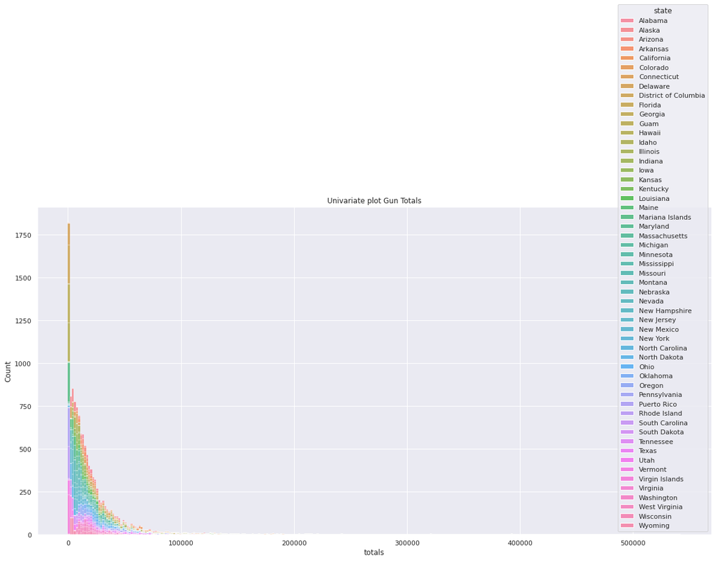

```python
#Before looking into the research question, will do a single variable analysis from the gun_df which is the "totals" column.
import seaborn as sns
#plotting the gun dataframe as a histogram, colored by state and type of histogram is stacked
sns.set(rc={'figure.figsize':(20,10)})
sns.histplot(data=gun_df, x="totals", hue="state", multiple="stack").set(title="Univariate plot Gun Totals")
```

- looking at the univariate plot above in gun_totals colored by state, the gun registration by number mostly lie between 0 and 100,000 per case.

```python
#Will break down month column in gun_df to year
gun_df['month'] = pd.to_datetime(gun_df['month'])
```

```python
#Getting month and year out of it
gun_df['year'] = gun_df['month'].dt.year
gun_df['month_num'] = gun_df['month'].dt.month
```

[output not shown]

[figure not shown]

```python
#Doing Bivariate analysis with time and Gun totals
#Before looking into the research question, will do a single variable analysis from the gun_df which is the "totals" column.
import seaborn as sns
#plotting the gun dataframe as a histogram, colored by state and type of histogram is stacked
sns.set(rc={'figure.figsize':(20,10)})
sns.lineplot(data=gun_df, x="totals", y="year").set(title="Bivariate plot Gun Totals over year")
```

**We could see from the Bivariate analysis that between 2012 and 2015, there was a spike in Gun totals of over 500,000

```python
 #raise SystemExit("Stop right there!")
```

```python
gun_df.head(2)
#previewing gun_df
```

[output not shown]

2 rows × 27 columns

```python
census_df.head(2)
```

| Fact | index | Population estimates, July 1, 2016, (V2016) | Population estimates base, April 1, 2010, (V2016) | Population, percent change - April 1, 2010 (estimates base) to July 1, 2016, (V2016) | Population, Census, April 1, 2010 | Persons under 5 years, percent, July 1, 2016, (V2016) | Persons under 5 years, percent, April 1, 2010 | Persons under 18 years, percent, July 1, 2016, (V2016) | Persons under 18 years, percent, April 1, 2010 | Persons 65 years and over, percent, July 1, 2016, (V2016) | ... | All firms, 2012 | Men-owned firms, 2012 | Women-owned firms, 2012 | Minority-owned firms, 2012 | Nonminority-owned firms, 2012 | Veteran-owned firms, 2012 | Nonveteran-owned firms, 2012 | Population per square mile, 2010 | Land area in square miles, 2010 | FIPS Code |
| --- | --- | --- | --- | --- | --- | --- | --- | --- | --- | --- | --- | --- | --- | --- | --- | --- | --- | --- | --- | --- | --- |
| 0 | Alabama | 4,863,300 | 4,780,131 | 1.70% | 4,779,736 | 6.00% | 6.40% | 22.60% | 23.70% | 16.10% | ... | 374,153 | 203,604 | 137,630 | 92,219 | 272,651 | 41,943 | 316,984 | 94.4 | 50,645.33 | "01" |
| 1 | Alaska | 741,894 | 710,249 | 4.50% | 710,231 | 7.30% | 7.60% | 25.20% | 26.40% | 10.40% | ... | 68,032 | 35,402 | 22,141 | 13,688 | 51,147 | 7,953 | 56,091 | 1.2 | 570,640.95 | "02" |

2 rows × 66 columns

```python
#renaming index column to state
census_df= census_df.rename(columns= {'index':'state'})
census_df.head(5)
```

| Fact | state | Population estimates, July 1, 2016, (V2016) | Population estimates base, April 1, 2010, (V2016) | Population, percent change - April 1, 2010 (estimates base) to July 1, 2016, (V2016) | Population, Census, April 1, 2010 | Persons under 5 years, percent, July 1, 2016, (V2016) | Persons under 5 years, percent, April 1, 2010 | Persons under 18 years, percent, July 1, 2016, (V2016) | Persons under 18 years, percent, April 1, 2010 | Persons 65 years and over, percent, July 1, 2016, (V2016) | ... | All firms, 2012 | Men-owned firms, 2012 | Women-owned firms, 2012 | Minority-owned firms, 2012 | Nonminority-owned firms, 2012 | Veteran-owned firms, 2012 | Nonveteran-owned firms, 2012 | Population per square mile, 2010 | Land area in square miles, 2010 | FIPS Code |
| --- | --- | --- | --- | --- | --- | --- | --- | --- | --- | --- | --- | --- | --- | --- | --- | --- | --- | --- | --- | --- | --- |
| 0 | Alabama | 4,863,300 | 4,780,131 | 1.70% | 4,779,736 | 6.00% | 6.40% | 22.60% | 23.70% | 16.10% | ... | 374,153 | 203,604 | 137,630 | 92,219 | 272,651 | 41,943 | 316,984 | 94.4 | 50,645.33 | "01" |
| 1 | Alaska | 741,894 | 710,249 | 4.50% | 710,231 | 7.30% | 7.60% | 25.20% | 26.40% | 10.40% | ... | 68,032 | 35,402 | 22,141 | 13,688 | 51,147 | 7,953 | 56,091 | 1.2 | 570,640.95 | "02" |
| 2 | Arizona | 6,931,071 | 6,392,301 | 8.40% | 6,392,017 | 6.30% | 7.10% | 23.50% | 25.50% | 16.90% | ... | 499,926 | 245,243 | 182,425 | 135,313 | 344,981 | 46,780 | 427,582 | 56.3 | 113,594.08 | "04" |
| 3 | Arkansas | 2,988,248 | 2,916,025 | 2.50% | 2,915,918 | 6.40% | 6.80% | 23.60% | 24.40% | 16.30% | ... | 231,959 | 123,158 | 75,962 | 35,982 | 189,029 | 25,915 | 192,988 | 56 | 52,035.48 | "05" |
| 4 | California | 39,250,017 | 37,254,522 | 5.40% | 37,253,956 | 6.30% | 6.80% | 23.20% | 25.00% | 13.60% | ... | 3,548,449 | 1,852,580 | 1,320,085 | 1,619,857 | 1,819,107 | 252,377 | 3,176,341 | 239.1 | 155,779.22 | "06" |

5 rows × 66 columns

```python
#now we join the two datasets gun_df and census_df on state
#using an inner join because I want to keep common states
#first checking again shape of both
print(census_df.shape)
print(gun_df.shape)
```

[output not shown]

```python
#Have to aggregate the 'state' column in gun_df , so it has unique state values aggregated by sum of all columns
#Before merging with census_df
grouped_gun_df=gun_df.groupby('state').sum().reset_index()
grouped_gun_df.head()
```

|  | state | multiple | totals |
| --- | --- | --- | --- |
| 0 | Alabama | 105230 | 6706079 |
| 1 | Alaska | 28904 | 1137643 |
| 2 | Arizona | 84979 | 4425714 |
| 3 | Arkansas | 61919 | 3752633 |
| 4 | California | 207864 | 19014063 |

```python
grouped_gun_df.shape
#Checking new shape
```

```
(55, 3)
```

```python
#joining grouped gun_df and census df on 'state' using inner join
joined_df = grouped_gun_df.merge(census_df, on='state', how='inner')
print(joined_df.shape)
joined_df
```

```
(50, 68)
```

|  | state | multiple | totals | Population estimates, July 1, 2016, (V2016) | Population estimates base, April 1, 2010, (V2016) | Population, percent change - April 1, 2010 (estimates base) to July 1, 2016, (V2016) | Population, Census, April 1, 2010 | Persons under 5 years, percent, July 1, 2016, (V2016) | Persons under 5 years, percent, April 1, 2010 | Persons under 18 years, percent, July 1, 2016, (V2016) | ... | All firms, 2012 | Men-owned firms, 2012 | Women-owned firms, 2012 | Minority-owned firms, 2012 | Nonminority-owned firms, 2012 | Veteran-owned firms, 2012 | Nonveteran-owned firms, 2012 | Population per square mile, 2010 | Land area in square miles, 2010 | FIPS Code |
| --- | --- | --- | --- | --- | --- | --- | --- | --- | --- | --- | --- | --- | --- | --- | --- | --- | --- | --- | --- | --- | --- |
| 0 | Alabama | 105230 | 6706079 | 4,863,300 | 4,780,131 | 1.70% | 4,779,736 | 6.00% | 6.40% | 22.60% | ... | 374,153 | 203,604 | 137,630 | 92,219 | 272,651 | 41,943 | 316,984 | 94.4 | 50,645.33 | "01" |
| 1 | Alaska | 28904 | 1137643 | 741,894 | 710,249 | 4.50% | 710,231 | 7.30% | 7.60% | 25.20% | ... | 68,032 | 35,402 | 22,141 | 13,688 | 51,147 | 7,953 | 56,091 | 1.2 | 570,640.95 | "02" |
| 2 | Arizona | 84979 | 4425714 | 6,931,071 | 6,392,301 | 8.40% | 6,392,017 | 6.30% | 7.10% | 23.50% | ... | 499,926 | 245,243 | 182,425 | 135,313 | 344,981 | 46,780 | 427,582 | 56.3 | 113,594.08 | "04" |
| 3 | Arkansas | 61919 | 3752633 | 2,988,248 | 2,916,025 | 2.50% | 2,915,918 | 6.40% | 6.80% | 23.60% | ... | 231,959 | 123,158 | 75,962 | 35,982 | 189,029 | 25,915 | 192,988 | 56 | 52,035.48 | "05" |
| 4 | California | 207864 | 19014063 | 39,250,017 | 37,254,522 | 5.40% | 37,253,956 | 6.30% | 6.80% | 23.20% | ... | 3,548,449 | 1,852,580 | 1,320,085 | 1,619,857 | 1,819,107 | 252,377 | 3,176,341 | 239.1 | 155,779.22 | "06" |
| 5 | Colorado | 306871 | 6058482 | 5,540,545 | 5,029,324 | 10.20% | 5,029,196 | 6.10% | 6.80% | 22.80% | ... | 547,352 | 284,554 | 194,508 | 85,849 | 442,365 | 51,722 | 469,524 | 48.5 | 103,641.89 | "08" |
| 6 | Connecticut | 8024 | 3168126 | 3,576,452 | 3,574,114 | 0.10% | 3,574,097 | 5.20% | 5.70% | 21.10% | ... | 326,693 | 187,845 | 106,678 | 56,113 | 259,614 | 31,056 | 281,182 | 738.1 | 4,842.36 | "09" |
| 7 | Delaware | 8269 | 491369 | 952,065 | 897,936 | 6.00% | 897,934 | 5.80% | 6.20% | 21.50% | ... | 73,418 | 38,328 | 23,964 | 14,440 | 54,782 | 7,206 | 60,318 | 460.8 | 1,948.54 | "10" |
| 8 | Florida | 242702 | 11695777 | 20,612,439 | 18,804,592 | 9.60% | 18,801,310 | 5.50% | 5.70% | 20.10% | ... | 2,100,187 | 1,084,885 | 807,817 | 926,112 | 1,121,749 | 185,756 | 1,846,686 | 350.6 | 53,624.76 | "12" |
| 9 | Georgia | 88396 | 7209942 | 10,310,371 | 9,688,680 | 6.40% | 9,687,653 | 6.40% | 7.10% | 24.40% | ... | 929,864 | 480,578 | 376,506 | 371,588 | 538,893 | 96,787 | 800,585 | 168.4 | 57,513.49 | "13" |
| 10 | Hawaii | 2 | 197580 | 1,428,557 | 1,360,301 | 5.00% | 1,360,301 | 6.40% | 6.40% | 21.60% | ... | 118,454 | 60,409 | 44,453 | 74,208 | 38,510 | 11,148 | 101,334 | 211.8 | 6,422.63 | "15" |
| 11 | Idaho | 31875 | 1968134 | 1,683,140 | 1,567,650 | 7.40% | 1,567,582 | 6.80% | 7.80% | 26.00% | ... | 146,642 | 70,438 | 45,121 | 10,592 | 130,973 | 12,804 | 124,314 | 19 | 82,643.12 | "16" |
| 12 | Illinois | 107550 | 15471534 | 12,801,539 | 12,831,574 | -0.20% | 12,830,632 | 6.00% | 6.50% | 22.90% | ... | 1,135,017 | 609,648 | 417,500 | 311,684 | 795,129 | 89,110 | 1,006,885 | 231.1 | 55,518.93 | "17" |
| 13 | Indiana | 76087 | 7737172 | 6,633,053 | 6,484,136 | 2.30% | 6,483,802 | 6.40% | 6.70% | 23.80% | ... | 479,059 | 253,533 | 162,798 | 61,252 | 405,090 | 45,174 | 412,543 | 181 | 35,826.11 | "18" |
| 14 | Iowa | 994 | 2297156 | 3,134,693 | 3,046,869 | 2.90% | 3,046,355 | 6.40% | 6.60% | 23.30% | ... | 259,121 | 135,382 | 82,345 | 14,707 | 236,561 | 25,889 | 217,779 | 54.5 | 55,857.13 | "19" |
| 15 | Kansas | 57331 | 2624669 | 2,907,289 | 2,853,129 | 1.90% | 2,853,118 | 6.70% | 7.20% | 24.60% | ... | 239,118 | 125,169 | 77,194 | 26,127 | 204,562 | 21,610 | 203,401 | 34.9 | 81,758.72 | "20" |
| 16 | Kentucky | 110439 | 29762434 | 4,436,974 | 4,339,344 | 2.20% | 4,339,367 | 6.20% | 6.50% | 22.80% | ... | 331,546 | 184,154 | 106,011 | 27,258 | 296,155 | 33,208 | 282,704 | 109.9 | 39,486.34 | "21" |
| 17 | Louisiana | 84852 | 4705057 | 4,681,666 | 4,533,479 | 3.30% | 4,533,372 | 6.60% | 6.90% | 23.80% | ... | 414,291 | 215,111 | 151,114 | 126,100 | 277,676 | 42,211 | 354,460 | 104.9 | 43,203.90 | "22" |
| 18 | Maine | 25168 | 1257457 | 1,331,479 | 1,328,364 | 0.20% | 1,328,361 | 4.90% | 5.20% | 19.10% | ... | 139,570 | 79,243 | 42,067 | 4,339 | 131,322 | 15,689 | 115,839 | 43.1 | 30,842.92 | "23" |
| 19 | Maryland | 2880 | 2035652 | 6,016,447 | 5,773,786 | 4.20% | 5,773,552 | 6.10% | 6.30% | 22.40% | ... | 531,953 | 276,630 | 209,119 | 203,394 | 314,902 | 50,976 | 462,232 | 594.8 | 9,707.24 | "24" |
| 20 | Massachusetts | 21081 | 2571321 | 6,811,779 | 6,547,813 | 4.00% | 6,547,629 | 5.30% | 5.60% | 20.20% | ... | 607,664 | 357,158 | 199,210 | 89,967 | 499,959 | 58,339 | 525,667 | 839.4 | 7,800.06 | "25" |
| 21 | Michigan | 20830 | 7254279 | 9,928,300 | 9,884,129 | 0.40% | 9,883,640 | 5.80% | 6.00% | 22.10% | ... | 834,087 | 446,128 | 306,986 | 158,946 | 657,237 | 71,861 | 733,517 | 174.8 | 56,538.90 | "26" |
| 22 | Minnesota | 47593 | 6279271 | 5,519,952 | 5,303,924 | 4.10% | 5,303,925 | 6.40% | 6.70% | 23.30% | ... | 489,494 | 268,710 | 157,821 | 47,302 | 428,716 | 45,582 | 419,628 | 66.6 | 79,626.74 | "27" |
| 23 | Mississippi | 58555 | 3576312 | 2,988,726 | 2,968,103 | 0.70% | 2,967,297 | 6.30% | 7.10% | 24.10% | ... | 235,454 | 125,079 | 89,159 | 74,824 | 155,094 | 26,789 | 198,566 | 63.2 | 46,923.27 | "28" |
| 24 | Missouri | 111418 | 6549018 | 6,093,000 | 5,988,928 | 1.70% | 5,988,927 | 6.10% | 6.50% | 22.80% | ... | 491,606 | 257,948 | 162,616 | 61,035 | 415,972 | 49,217 | 415,542 | 87.1 | 68,741.52 | "29" |
| 25 | Montana | 38373 | 1884124 | 1,042,520 | 989,414 | 5.40% | 989,415 | 6.00% | 6.30% | 21.80% | ... | 112,419 | 55,913 | 35,449 | 5,578 | 102,746 | 11,486 | 93,393 | 6.8 | 145,545.80 | "30" |
| 26 | Nebraska | 714 | 1136209 | 1,907,116 | 1,826,334 | 4.40% | 1,826,341 | 7.00% | 7.20% | 24.80% | ... | 164,089 | 83,696 | 51,936 | 14,571 | 144,122 | 16,693 | 137,254 | 23.8 | 76,824.17 | "31" |
| 27 | Nevada | 47035 | 1731797 | 2,940,058 | 2,700,691 | 8.90% | 2,700,551 | 6.30% | 6.90% | 23.00% | ... | 227,156 | 114,057 | 82,508 | 71,864 | 144,944 | 23,049 | 191,293 | 24.6 | 109,781.18 | "32" |
| 28 | New Hampshire | 2098 | 1583148 | 1,334,795 | 1,316,461 | 1.40% | 1,316,470 | 4.80% | 5.30% | 19.50% | ... | 131,638 | 76,716 | 38,525 | 6,111 | 121,297 | 16,119 | 108,817 | 147 | 8,952.65 | "33" |
| 29 | New Jersey | 8762 | 1145846 | 8,944,469 | 8,791,953 | 1.70% | 8,791,894 | 5.80% | 6.20% | 22.20% | ... | 792,088 | 464,592 | 252,944 | 237,242 | 533,808 | 57,996 | 707,975 | 1,195.50 | 7,354.22 | "34" |
| 30 | New Mexico | 46782 | 2076591 | 2081015 | 2059198 | 0.011 | 2059179 | 0.062 | 0.07 | 0.236 | ... | 151363 | 71132 | 59044 | 60622 | 83857 | 14096 | 128693 | 17 | 121298.15 | "35" |
| 31 | New York | 18256 | 4643828 | 19745289 | 19378110 | 0.019 | 19378102 | 0.059 | 0.06 | 0.212 | ... | 2008988 | 1139910 | 725709 | 709021 | 1248304 | 137532 | 1811544 | 411.2 | 47126.4 | "36" |
| 32 | North Carolina | 36080 | 7777689 | 10146788 | 9535688 | 0.064 | 9535483 | 0.06 | 0.066 | 0.227 | ... | 805985 | 435677 | 287058 | 183380 | 603182 | 86571 | 684743 | 196.1 | 48617.91 | "37" |
| 33 | North Dakota | 10580 | 947440 | 757952 | 672591 | 0.127 | 672591 | 0.073 | 0.066 | 0.233 | ... | 68270 | 37016 | 20316 | 3190 | 62271 | 6584 | 56904 | 9.7 | 69000.8 | "38" |
| 34 | Ohio | 179115 | 8462744 | 11614373 | 11536727 | 0.007 | 11536504 | 0.06 | 0.062 | 0.225 | ... | 904814 | 510078 | 306824 | 122653 | 759569 | 91316 | 776193 | 282.3 | 40860.69 | "39" |
| 35 | Oklahoma | 126347 | 4584454 | 3923561 | 3751615 | 0.046 | 3751351 | 0.068 | 0.07 | 0.245 | ... | 327229 | 174395 | 105168 | 64875 | 249027 | 36273 | 273491 | 54.7 | 68594.92 | "40" |
| 36 | Oregon | 47319 | 3751061 | 4093465 | 3831072 | 0.068 | 3831074 | 0.058 | 0.062 | 0.212 | ... | 339305 | 165691 | 123015 | 41456 | 285028 | 30918 | 288790 | 39.9 | 95988.01 | "41" |
| 37 | Pennsylvania | 59386 | 13133876 | 12784227 | 12702857 | 0.006 | 12702379 | 0.056 | 0.057 | 0.209 | ... | 975453 | 579400 | 304803 | 131512 | 818858 | 97969 | 837792 | 283.9 | 44742.7 | "42" |
| 38 | Rhode Island | 23385 | 288870 | 1056426 | 1052940 | 0.003 | 1052567 | 0.052 | 0.055 | 0.197 | ... | 94642 | 54651 | 30484 | 14737 | 77042 | 9904 | 79837 | 1018.1 | 1033.81 | "44" |
| 39 | South Carolina | 50006 | 4014432 | 4961119 | 4625410 | 0.073 | 4625364 | 0.059 | 0.065 | 0.221 | ... | 367726 | 202446 | 131856 | 83233 | 276269 | 47987 | 303137 | 153.9 | 30060.7 | "45" |
| 40 | South Dakota | 19786 | 1215712 | 865454 | 814195 | 0.063 | 814180 | 0.071 | 0.073 | 0.246 | ... | 81314 | 42418 | 23722 | 4101 | 74228 | 8604 | 66219 | 10.7 | 75811 | "46" |
| 41 | Tennessee | 117354 | 7311293 | 6651194 | 6346298 | 0.048 | 6346105 | 0.061 | 0.064 | 0.226 | ... | 550453 | 302249 | 195694 | 105234 | 434025 | 59379 | 469392 | 153.9 | 41234.9 | "47" |
| 42 | Texas | 367962 | 19435186 | 27,862,596 | 25,146,100 | 10.80% | 25,145,561 | 7.20% | 7.70% | 26.20% | ... | 2,356,748 | 1,251,696 | 866,678 | 1,070,392 | 1,224,845 | 213,590 | 2,057,218 | 96.3 | 261,231.71 | "48" |
| 43 | Utah | 25427 | 4338273 | 3,051,217 | 2,763,888 | 10.40% | 2,763,885 | 8.30% | 9.50% | 30.20% | ... | 251,419 | 132,163 | 76,269 | 24,423 | 218,826 | 18,754 | 219,807 | 33.6 | 82,169.62 | "49" |
| 44 | Vermont | 8085 | 484447 | 624,594 | 625,741 | -0.20% | 625,741 | 4.90% | 5.10% | 19.00% | ... | 75,827 | 41,270 | 23,417 | 2,354 | 70,491 | 8,237 | 63,317 | 67.9 | 9,216.66 | "50" |
| 45 | Virginia | 42253 | 5878675 | 8,411,808 | 8,001,041 | 5.10% | 8,001,024 | 6.10% | 6.40% | 22.20% | ... | 653,193 | 353,012 | 236,290 | 185,043 | 450,109 | 76,434 | 548,439 | 202.6 | 39,490.09 | "51" |
| 46 | Washington | 86202 | 6384517 | 7,288,000 | 6,724,545 | 8.40% | 6,724,540 | 6.20% | 6.50% | 22.40% | ... | 541,522 | 262,650 | 187,677 | 92,807 | 426,697 | 49,331 | 461,401 | 101.2 | 66,455.52 | "53" |
| 47 | West Virginia | 66790 | 3208889 | 1,831,102 | 1,853,011 | -1.20% | 1,852,994 | 5.50% | 5.60% | 20.50% | ... | 114,435 | 63,112 | 39,065 | 5,777 | 104,785 | 12,912 | 94,960 | 77.1 | 24,038.21 | "54" |
| 48 | Wisconsin | 3927 | 5131725 | 5,778,708 | 5,687,289 | 1.60% | 5,686,986 | 5.80% | 6.30% | 22.30% | ... | 432,980 | 236,252 | 133,859 | 40,507 | 379,934 | 39,830 | 370,755 | 105 | 54,157.80 | "55" |
| 49 | Wyoming | 17088 | 894306 | 585,501 | 563,767 | 3.90% | 563,626 | 6.50% | 7.10% | 23.70% | ... | 62,427 | 30,039 | 19,344 | 4,077 | 55,397 | 6,470 | 51,353 | 5.8 | 97,093.14 | "56" |

50 rows × 68 columns

##### After merging both documents on state, will now look at state with highest gun per capita

```python
#columns to use from the gun_df is 'totals', and for the census data 'Population estimates, July 1, 2016,  (V2016)'
#checking if columns are of same data type
print(joined_df['Population estimates, July 1, 2016,  (V2016)'].dtypes)
print(joined_df['totals'].dtypes)
```

```
object
int64
```

```python
#they are different, so conversion needed for 'Population estimates' column
#looking at how object looks
joined_df['Population estimates, July 1, 2016,  (V2016)'].unique
```

```
<bound method Series.unique of 0      4,863,300
1        741,894
2      6,931,071
3      2,988,248
4     39,250,017
5      5,540,545
6      3,576,452
7        952,065
8     20,612,439
9     10,310,371
10     1,428,557
11     1,683,140
12    12,801,539
13     6,633,053
14     3,134,693
```

[output cut: 36 more lines]

```python
#Have to strip the commas from this data, then convert to int or float
joined_df['Population estimates, July 1, 2016,  (V2016)'] = joined_df['Population estimates, July 1, 2016,  (V2016)'].str.replace(',', '').astype(float)
joined_df['Population estimates, July 1, 2016,  (V2016)'].dtypes
```

```
dtype('float64')
```

```python
#looking at columns
joined_df.columns
```

```
Index(['state', 'multiple', 'totals',
       'Population estimates, July 1, 2016,  (V2016)',
       'Population estimates base, April 1, 2010,  (V2016)',
       'Population, percent change - April 1, 2010 (estimates base) to July 1, 2016,  (V2016)',
       'Population, Census, April 1, 2010',
       'Persons under 5 years, percent, July 1, 2016,  (V2016)',
       'Persons under 5 years, percent, April 1, 2010',
       'Persons under 18 years, percent, July 1, 2016,  (V2016)',
       'Persons under 18 years, percent, April 1, 2010',
       'Persons 65 years and over, percent,  July 1, 2016,  (V2016)',
       'Persons 65 years and over, percent, April 1, 2010',
       'Female persons, percent,  July 1, 2016,  (V2016)',
       'Female persons, percent, April 1, 2010',
       'White alone, percent, July 1, 2016,  (V2016)',
       'Black or African American alone, percent, July 1, 2016,  (V2016)',
       'American Indian and Alaska Native alone, percent, July 1, 2016,  (V2016)',
       'Asian alone, percent, July 1, 2016,  (V2016)',
       'Native Hawaiian and Other Pacific Islander alone, percent, July 1, 2016,  (V2016)',
       'Two or More Races, percent, July 1, 2016,  (V2016)',
       'Hispanic or Latino, percent, July 1, 2016,  (V2016)',
       'White alone, not Hispanic or Latino, percent, July 1, 2016,  (V2016)',
       'Veterans, 2011-2015', 'Foreign born persons, percent, 2011-2015',
       'Housing units,  July 1, 2016,  (V2016)',
       'Housing units, April 1, 2010',
       'Owner-occupied housing unit rate, 2011-2015',
       'Median value of owner-occupied housing units, 2011-2015',
       'Median selected monthly owner costs -with a mortgage, 2011-2015',
       'Median selected monthly owner costs -without a mortgage, 2011-2015',
       'Median gross rent, 2011-2015', 'Building permits, 2016',
       'Households, 2011-2015', 'Persons per household, 2011-2015',
       'Living in same house 1 year ago, percent of persons age 1 year+, 2011-2015',
       'Language other than English spoken at home, percent of persons age 5 years+, 2011-2015',
       'High school graduate or higher, percent of persons age 25 years+, 2011-2015',
       'Bachelor's degree or higher, percent of persons age 25 years+, 2011-2015',
       'With a disability, under age 65 years, percent, 2011-2015',
       'Persons  without health insurance, under age 65 years, percent',
       'In civilian labor force, total, percent of population age 16 years+, 2011-2015',
       'In civilian labor force, female, percent of population age 16 years+, 2011-2015',
       'Total accommodation and food services sales, 2012 ($1,000)',
       'Total health care and social assistance receipts/revenue, 2012 ($1,000)',
       'Total manufacturers shipments, 2012 ($1,000)',
       'Total merchant wholesaler sales, 2012 ($1,000)',
       'Total retail sales, 2012 ($1,000)',
       'Total retail sales per capita, 2012',
       'Mean travel time to work (minutes), workers age 16 years+, 2011-2015',
       'Median household income (in 2015 dollars), 2011-2015',
       'Per capita income in past 12 months (in 2015 dollars), 2011-2015',
       'Persons in poverty, percent', 'Total employer establishments, 2015',
       'Total employment, 2015', 'Total annual payroll, 2015 ($1,000)',
       'Total employment, percent change, 2014-2015',
       'Total nonemployer establishments, 2015', 'All firms, 2012',
       'Men-owned firms, 2012', 'Women-owned firms, 2012',
       'Minority-owned firms, 2012', 'Nonminority-owned firms, 2012',
       'Veteran-owned firms, 2012', 'Nonveteran-owned firms, 2012',
       'Population per square mile, 2010', 'Land area in square miles, 2010',
       'FIPS Code'],
      dtype='object')
```

```python
#now we can perform the operation and find the highest gun per capita state
joined_df['gun_per_capita']=joined_df['totals']/joined_df['Population estimates, July 1, 2016,  (V2016)']
joined_df.loc[:,['gun_per_capita','totals','Population estimates, July 1, 2016,  (V2016)','state']].sort_values('gun_per_capita',ascending=False)
```

|  | gun_per_capita | totals | Population estimates, July 1, 2016, (V2016) | state |
| --- | --- | --- | --- | --- |
| 16 | 6.707822 | 29762434 | 4436974.0 | Kentucky |
| 25 | 1.807279 | 1884124 | 1042520.0 | Montana |
| 47 | 1.752436 | 3208889 | 1831102.0 | West Virginia |
| 1 | 1.533431 | 1137643 | 741894.0 | Alaska |
| 49 | 1.527420 | 894306 | 585501.0 | Wyoming |
| 43 | 1.421817 | 4338273 | 3051217.0 | Utah |
| 40 | 1.404710 | 1215712 | 865454.0 | South Dakota |
| 0 | 1.378915 | 6706079 | 4863300.0 | Alabama |
| 3 | 1.255797 | 3752633 | 2988248.0 | Arkansas |
| 33 | 1.250000 | 947440 | 757952.0 | North Dakota |
| 12 | 1.208568 | 15471534 | 12801539.0 | Illinois |
| 23 | 1.196601 | 3576312 | 2988726.0 | Mississippi |
| 28 | 1.186061 | 1583148 | 1334795.0 | New Hampshire |
| 11 | 1.169323 | 1968134 | 1683140.0 | Idaho |
| 35 | 1.168442 | 4584454 | 3923561.0 | Oklahoma |
| 13 | 1.166457 | 7737172 | 6633053.0 | Indiana |
| 22 | 1.137559 | 6279271 | 5519952.0 | Minnesota |
| 41 | 1.099245 | 7311293 | 6651194.0 | Tennessee |
| 5 | 1.093481 | 6058482 | 5540545.0 | Colorado |
| 24 | 1.074843 | 6549018 | 6093000.0 | Missouri |
| 37 | 1.027350 | 13133876 | 12784227.0 | Pennsylvania |
| 17 | 1.004996 | 4705057 | 4681666.0 | Louisiana |
| 30 | 0.997874 | 2076591 | 2081015.0 | New Mexico |
| 18 | 0.944406 | 1257457 | 1331479.0 | Maine |
| 36 | 0.916354 | 3751061 | 4093465.0 | Oregon |
| 15 | 0.902789 | 2624669 | 2907289.0 | Kansas |
| 48 | 0.888040 | 5131725 | 5778708.0 | Wisconsin |
| 6 | 0.885829 | 3168126 | 3576452.0 | Connecticut |
| 46 | 0.876031 | 6384517 | 7288000.0 | Washington |
| 39 | 0.809179 | 4014432 | 4961119.0 | South Carolina |
| 44 | 0.775619 | 484447 | 624594.0 | Vermont |
| 32 | 0.766517 | 7777689 | 10146788.0 | North Carolina |
| 14 | 0.732817 | 2297156 | 3134693.0 | Iowa |
| 21 | 0.730667 | 7254279 | 9928300.0 | Michigan |
| 34 | 0.728644 | 8462744 | 11614373.0 | Ohio |
| 9 | 0.699290 | 7209942 | 10310371.0 | Georgia |
| 45 | 0.698860 | 5878675 | 8411808.0 | Virginia |
| 42 | 0.697537 | 19435186 | 27862596.0 | Texas |
| 2 | 0.638532 | 4425714 | 6931071.0 | Arizona |
| 26 | 0.595773 | 1136209 | 1907116.0 | Nebraska |
| 27 | 0.589035 | 1731797 | 2940058.0 | Nevada |
| 8 | 0.567414 | 11695777 | 20612439.0 | Florida |
| 7 | 0.516109 | 491369 | 952065.0 | Delaware |
| 4 | 0.484435 | 19014063 | 39250017.0 | California |
| 20 | 0.377482 | 2571321 | 6811779.0 | Massachusetts |
| 19 | 0.338348 | 2035652 | 6016447.0 | Maryland |
| 38 | 0.273441 | 288870 | 1056426.0 | Rhode Island |
| 31 | 0.235187 | 4643828 | 19745289.0 | New York |
| 10 | 0.138307 | 197580 | 1428557.0 | Hawaii |
| 29 | 0.128107 | 1145846 | 8944469.0 | New Jersey |

```
[Text(0.5, 1.0, 'Line plot gun_per_capita by state')]
```

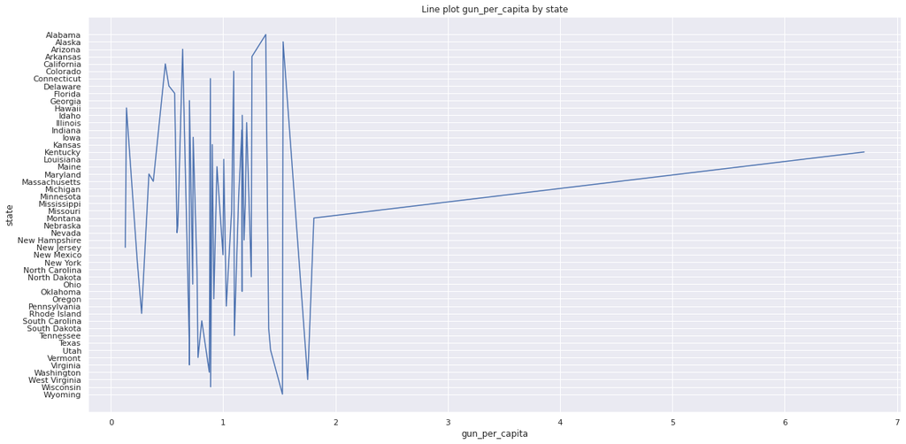

```python
#Looking at a plot of gun_per_capita by state
import seaborn as sns
#plotting the joined dataframe as a lineplot with gun per capita and state
sns.set(rc={'figure.figsize':(20,10)})
sns.lineplot(data=joined_df, x="gun_per_capita", y="state").set(title="Line plot gun_per_capita by state")
```

```python
#looking at the lowest ones
joined_df.loc[:,['gun_per_capita','totals','Population estimates, July 1, 2016,  (V2016)','state']].sort_values('gun_per_capita',ascending=True)
```

|  | gun_per_capita | totals | Population estimates, July 1, 2016, (V2016) | state |
| --- | --- | --- | --- | --- |
| 29 | 0.128107 | 1145846 | 8944469.0 | New Jersey |
| 10 | 0.138307 | 197580 | 1428557.0 | Hawaii |
| 31 | 0.235187 | 4643828 | 19745289.0 | New York |
| 38 | 0.273441 | 288870 | 1056426.0 | Rhode Island |
| 19 | 0.338348 | 2035652 | 6016447.0 | Maryland |
| 20 | 0.377482 | 2571321 | 6811779.0 | Massachusetts |
| 4 | 0.484435 | 19014063 | 39250017.0 | California |
| 7 | 0.516109 | 491369 | 952065.0 | Delaware |
| 8 | 0.567414 | 11695777 | 20612439.0 | Florida |
| 27 | 0.589035 | 1731797 | 2940058.0 | Nevada |
| 26 | 0.595773 | 1136209 | 1907116.0 | Nebraska |
| 2 | 0.638532 | 4425714 | 6931071.0 | Arizona |
| 42 | 0.697537 | 19435186 | 27862596.0 | Texas |
| 45 | 0.698860 | 5878675 | 8411808.0 | Virginia |
| 9 | 0.699290 | 7209942 | 10310371.0 | Georgia |
| 34 | 0.728644 | 8462744 | 11614373.0 | Ohio |
| 21 | 0.730667 | 7254279 | 9928300.0 | Michigan |
| 14 | 0.732817 | 2297156 | 3134693.0 | Iowa |
| 32 | 0.766517 | 7777689 | 10146788.0 | North Carolina |
| 44 | 0.775619 | 484447 | 624594.0 | Vermont |
| 39 | 0.809179 | 4014432 | 4961119.0 | South Carolina |
| 46 | 0.876031 | 6384517 | 7288000.0 | Washington |
| 6 | 0.885829 | 3168126 | 3576452.0 | Connecticut |
| 48 | 0.888040 | 5131725 | 5778708.0 | Wisconsin |
| 15 | 0.902789 | 2624669 | 2907289.0 | Kansas |
| 36 | 0.916354 | 3751061 | 4093465.0 | Oregon |
| 18 | 0.944406 | 1257457 | 1331479.0 | Maine |
| 30 | 0.997874 | 2076591 | 2081015.0 | New Mexico |
| 17 | 1.004996 | 4705057 | 4681666.0 | Louisiana |
| 37 | 1.027350 | 13133876 | 12784227.0 | Pennsylvania |
| 24 | 1.074843 | 6549018 | 6093000.0 | Missouri |
| 5 | 1.093481 | 6058482 | 5540545.0 | Colorado |
| 41 | 1.099245 | 7311293 | 6651194.0 | Tennessee |
| 22 | 1.137559 | 6279271 | 5519952.0 | Minnesota |
| 13 | 1.166457 | 7737172 | 6633053.0 | Indiana |
| 35 | 1.168442 | 4584454 | 3923561.0 | Oklahoma |
| 11 | 1.169323 | 1968134 | 1683140.0 | Idaho |
| 28 | 1.186061 | 1583148 | 1334795.0 | New Hampshire |
| 23 | 1.196601 | 3576312 | 2988726.0 | Mississippi |
| 12 | 1.208568 | 15471534 | 12801539.0 | Illinois |
| 33 | 1.250000 | 947440 | 757952.0 | North Dakota |
| 3 | 1.255797 | 3752633 | 2988248.0 | Arkansas |
| 0 | 1.378915 | 6706079 | 4863300.0 | Alabama |
| 40 | 1.404710 | 1215712 | 865454.0 | South Dakota |
| 43 | 1.421817 | 4338273 | 3051217.0 | Utah |
| 49 | 1.527420 | 894306 | 585501.0 | Wyoming |
| 1 | 1.533431 | 1137643 | 741894.0 | Alaska |
| 47 | 1.752436 | 3208889 | 1831102.0 | West Virginia |
| 25 | 1.807279 | 1884124 | 1042520.0 | Montana |
| 16 | 6.707822 | 29762434 | 4436974.0 | Kentucky |